# Sesión 06: Series Temporales - Función de Transferencia

Master en Data Science: Predicción

Ricardo A. Queralt @Cunef - V1.12

Este documento ha sido preparado por Ricardo A. Queralt, profesor de Finanzas Cuantitativas para ser utilizado como material de análisis y estudio. De ninguna forma pretende ilustrar recomendaciones de actuación sobre las empresas, las situaciones, o las personas mencionadas en el documento. Las propuestas conceptuales, opiniones y análisis que aparecen en este documento son responsabilidad del autor y, por lo tanto, no necesariamente coinciden con las de CUNEF.

Este documento no podrá ser reproducido, almacenado, utilizado o transmitido por ningún medio (fotocopia, copia digital, envío electrónico,…) sin autorización escrita del autor y/o CUNEF

**©Ricardo A. Queralt & CUNEF.**

# Librerias

```r
library(tidyverse)
library(tsibble)

library(TSA)
library(Hmisc)
library(astsa)
library(dynlm)
library(feasts)
```

# Read data from

```r
sales_140
```

```
Time Series:
Start = 1
End = 140
Frequency = 1
  [1] 200.1 199.5 199.4 198.9 199.0 200.2 198.6 200.0 200.3 201.2 201.6 201.5 201.5 203.5 204.9 207.1
 [17] 210.5 210.5 209.8 208.8 209.5 213.2 213.7 215.1 218.7 219.8 220.5 223.8 222.8 223.8 221.7 222.3
 [33] 220.8 219.4 220.1 220.6 218.9 217.8 217.7 215.0 215.3 215.9 216.7 216.7 217.7 218.7 222.9 224.9
 [49] 222.2 220.7 220.0 218.7 217.0 215.9 215.8 214.1 212.3 213.9 214.6 213.6 212.1 211.4 213.1 212.9
 [65] 213.3 211.5 212.3 213.0 211.0 210.7 210.1 211.4 210.0 209.7 208.8 208.8 208.8 210.6 211.9 212.8
 [81] 212.5 214.8 215.3 217.5 218.8 220.7 222.2 226.7 228.4 233.2 235.7 237.1 240.6 243.8 245.3 246.0
 [97] 246.3 247.7 247.6 247.8 249.4 249.0 249.9 250.5 251.5 249.0 247.6 248.8 250.4 250.7 253.0 253.7
[113] 255.0 256.2 256.0 257.4 260.4 260.0 261.3 260.4 261.6 260.8 259.8 259.0 258.9 257.4 257.7 257.9
[129] 257.4 257.3 257.6 258.9 257.8 257.7 257.2 257.5 256.8 257.5 257.0 257.6
```

# Plot Data

```
Plot variable not specified, automatically selected `.vars = value`
```

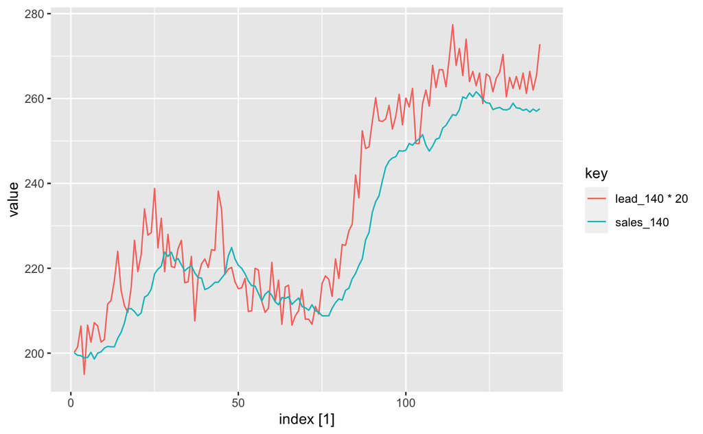

```r
autoplot(as_tsibble(data))
```